# Self-Driving Car Engineer Nanodegree

## Project: Build a Traffic Sign Recognition Classifier

In this notebook, a template is provided for you to implement your functionality in stages which is required to successfully complete this project. If additional code is required that cannot be included in the notebook, be sure that the Python code is successfully imported and included in your submission, if necessary. Sections that begin with **'Implementation'** in the header indicate where you should begin your implementation for your project. Note that some sections of implementation are optional, and will be marked with **'Optional'** in the header.

In addition to implementing code, there will be questions that you must answer which relate to the project and your implementation. Each section where you will answer a question is preceded by a **'Question'** header. Carefully read each question and provide thorough answers in the following text boxes that begin with **'Answer:'**. Your project submission will be evaluated based on your answers to each of the questions and the implementation you provide.

> **Note:** Code and Markdown cells can be executed using the **Shift + Enter** keyboard shortcut. In addition, Markdown cells can be edited by typically double-clicking the cell to enter edit mode.

## Step 0: Load The Data

```python
# Load pickled data
import pickle
import numpy as np
import pandas as pd

# TODO: Fill this in based on where you saved the training and testing data

training_file = "./train.p"
testing_file = "./test.p"

with open(training_file, mode='rb') as f:
    train = pickle.load(f)
with open(testing_file, mode='rb') as f:
    test = pickle.load(f)

signnames_file = "signnames.csv"
signnames = pd.read_csv(signnames_file)

from sklearn.utils import shuffle

#X_train, y_train = shuffle( np.array(train['features']), np.array(train['labels']), n_samples=2000, random_state=1229)
#X_test, y_test = shuffle (np.array(test['features']), np.array(test['labels']), n_samples=400, random_state=1229)

X_train, y_train = np.array(train['features']), np.array(train['labels'])
X_test, y_test = np.array(test['features']), np.array(test['labels'])
```

## Step 1: Dataset Summary & Exploration

The pickled data is a dictionary with 4 key/value pairs:

- `'features'` is a 4D array containing raw pixel data of the traffic sign images, (num examples, width, height, channels).
- `'labels'` is a 2D array containing the label/class id of the traffic sign. The file `signnames.csv` contains id -> name mappings for each id.
- `'sizes'` is a list containing tuples, (width, height) representing the the original width and height the image.
- `'coords'` is a list containing tuples, (x1, y1, x2, y2) representing coordinates of a bounding box around the sign in the image. **THESE COORDINATES ASSUME THE ORIGINAL IMAGE. THE PICKLED DATA CONTAINS RESIZED VERSIONS (32 by 32) OF THESE IMAGES**

Complete the basic data summary below.

```python
### Replace each question mark with the appropriate value.

# TODO: Number of training examples
n_train = X_train.shape[0]

# TODO: Number of testing examples.
n_test = X_test.shape[0]

# TODO: What's the shape of an traffic sign image?
image_shape = X_train[0].shape

# TODO: How many unique classes/labels there are in the dataset.
n_classes = np.unique(y_train).shape[0]

print("Number of training examples =", n_train)
print("Number of testing examples =", n_test)
print("Image data shape =", image_shape)
print("Number of classes =", n_classes)
```

```
Number of training examples = 39209
Number of testing examples = 12630
Image data shape = (32, 32, 3)
Number of classes = 43
```

Visualize the German Traffic Signs Dataset using the pickled file(s). This is open ended, suggestions include: plotting traffic sign images, plotting the count of each sign, etc.

The [Matplotlib](http://matplotlib.org/) [examples](http://matplotlib.org/examples/index.html) and [gallery](http://matplotlib.org/gallery.html) pages are a great resource for doing visualizations in Python.

**NOTE:** It's recommended you start with something simple first. If you wish to do more, come back to it after you've completed the rest of the sections.

```python
### Data exploration visualization goes here.
### Feel free to use as many code cells as needed.
import matplotlib.pyplot as plt
# Visualizations will be shown in the notebook.
%matplotlib inline
import scipy.ndimage
import cv2
from tqdm import tqdm
import os
from PIL import Image
```

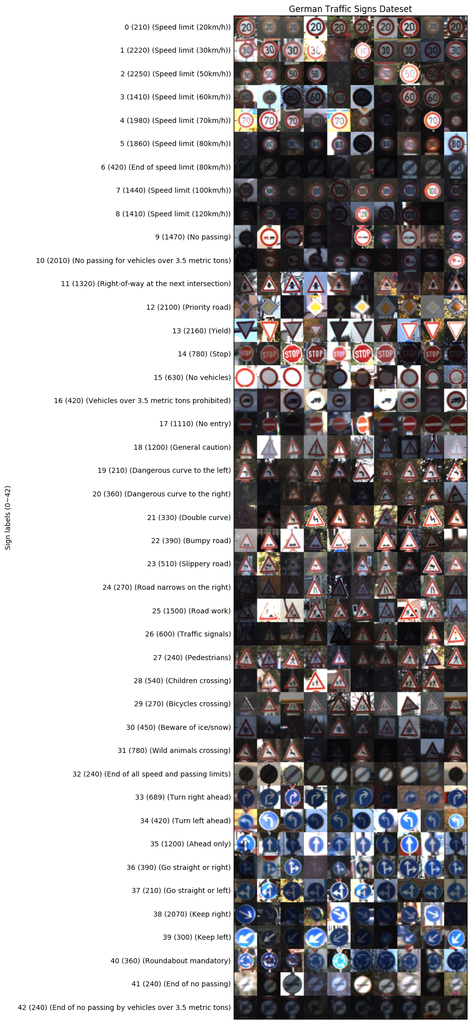

```python
# create container canvas_
canvas_ = np.empty(shape=[0,320,3], dtype='uint8')
plt.figure(figsize=(6,40))
ytitle = []

for label_i in np.arange(n_classes):
    # select indices of the same signs
    signs_pool = np.where(y_train==label_i)
    # Randomly select 10 indices from the signs_pool
    signs_samples = np.random.choice(len(signs_pool[0]), 10)
    # Initialize the canvas for each 10 same signs
    canvas = np.empty(shape = [32,0,3],dtype='uint8')
    for sample_idx in signs_samples:
        idx_sign = signs_pool[0][sample_idx]
        img_sign = X_train[idx_sign]
        canvas=np.append(canvas, img_sign, axis=1)
    canvas_ = np.append(canvas_, canvas, axis=0)
    str1 = ' {0} ({1}) ({2})'.format(label_i, np.count_nonzero(y_train == label_i), signnames.SignName[label_i])
    ytitle.append(str1)

plt.imshow(canvas_);
y_pos = np.arange(n_classes)*32+16
plt.yticks(y_pos, ytitle)
plt.xticks([])
plt.ylabel('Sign labels (0~42)')
plt.title('German Traffic Signs Dateset')
plt.show()
```

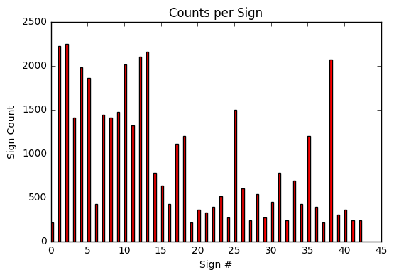

```python
def showHistogram():
    counts = np.bincount(y_train)
    countsFig = plt.figure()
    countsFigPlt = countsFig.add_subplot(111)
    countsFigPlt.set_ylabel('Sign Count')
    countsFigPlt.set_xlabel('Sign #')
    countsFigPlt.set_title('Counts per Sign')
    countsFigPlt.bar(range(len(counts)), counts, 1/3, color='red', label='Counts per Sign')
    plt.show()

showHistogram()
```

## Step 2: Design and Test a Model Architecture

Design and implement a deep learning model that learns to recognize traffic signs. Train and test your model on the [German Traffic Sign Dataset](http://benchmark.ini.rub.de/?section=gtsrb&subsection=dataset).

There are various aspects to consider when thinking about this problem:

- Neural network architecture
- Play around preprocessing techniques (normalization, rgb to grayscale, etc)
- Number of examples per label (some have more than others).
- Generate fake data.

Here is an example of a [published baseline model on this problem](http://yann.lecun.com/exdb/publis/pdf/sermanet-ijcnn-11.pdf). It's not required to be familiar with the approach used in the paper but, it's good practice to try to read papers like these.

**NOTE:** The LeNet-5 implementation shown in the classroom at the end of the CNN lesson is a solid starting point. You'll have to change the number of classes and possibly the preprocessing, but aside from that it's plug and play!

### Implementation

Use the code cell (or multiple code cells, if necessary) to implement the first step of your project. Once you have completed your implementation and are satisfied with the results, be sure to thoroughly answer the questions that follow.

```python
from sklearn.model_selection import train_test_split
X_train, X_valid, y_train, y_valid = train_test_split(X_train, y_train,test_size=0.2,random_state=1229)
```

```python
### Preprocess the data here.
### Feel free to use as many code cells as needed.
def addRotatedImages():
    print('Generating additional data by rotating images...')
    angles = [-5, 5, -10, 10, -15, 15, -20, 20]
    new_features = []
    new_labels = []
    counts = np.bincount(y_train)
    maxcounts = max(counts)
    for i in range(len(counts)):
        multiplier = min(int(maxcounts / counts[i]) - 1, len(angles) - 1)
        if multiplier <= 1:
            continue
        mask = np.where(y_train == i)
        for j in range(multiplier):
            for feature in X_train[mask]:
                new_features.append(scipy.ndimage.rotate(feature, angles[j], reshape=False))
                new_labels.append(i)

    print("generated {} new data".format(len(new_features)))
    return new_features,new_labels
```

```python
def transform_image(img,ang_range,shear_range,trans_range):
    '''
    This function transforms images to generate new images.
    The function takes in following arguments,
    1- Image
    2- ang_range: Range of angles for rotation
    3- shear_range: Range of values to apply affine transform to
    4- trans_range: Range of values to apply translations over.

    A Random uniform distribution is used to generate different parameters for transformation

    '''
    # Rotation

    ang_rot = np.random.uniform(ang_range)-ang_range/2
    rows,cols,ch = img.shape
    Rot_M = cv2.getRotationMatrix2D((cols/2,rows/2),ang_rot,1)

    # Translation
    tr_x = trans_range*np.random.uniform()-trans_range/2
    tr_y = trans_range*np.random.uniform()-trans_range/2
    Trans_M = np.float32([[1,0,tr_x],[0,1,tr_y]])

    # Shear
    pts1 = np.float32([[5,5],[20,5],[5,20]])

    pt1 = 5+shear_range*np.random.uniform()-shear_range/2
    pt2 = 20+shear_range*np.random.uniform()-shear_range/2

    pts2 = np.float32([[pt1,5],[pt2,pt1],[5,pt2]])

    shear_M = cv2.getAffineTransform(pts1,pts2)

    img = cv2.warpAffine(img,Rot_M,(cols,rows))
    img = cv2.warpAffine(img,Trans_M,(cols,rows))
    img = cv2.warpAffine(img,shear_M,(cols,rows))

    return img
```

```python
def addImages():
    print('Generating additional data by transforming  images...')
    new_features = []
    new_labels = []
    angles_range = 20
    shear_range = 10
    trans_range = 5
    counts = np.bincount(y_train)
    maxcounts = max(counts)
    for i in range(len(counts)):
        if not counts[i]:
            continue
        multiplier = min (int(maxcounts / counts[i]) - 1, 10) # synthetic multiplier of ratio or max 10
        if multiplier <= 1:
            continue
        mask = np.where(y_train == i)
        for j in range(multiplier):
            for feature in X_train[mask]:
                new_features.append(transform_image(feature, angles_range, shear_range, trans_range))
                new_labels.append(i)

    print("generated {} new data".format(len(new_features)))
    return new_features,new_labels
```

```python
#data normalization parameter, save for later use
centerBy = np.mean(X_train)
```

```python
#center Data
X_train = X_train - centerBy
```

```python
#normalizeData
X_train  = X_train/255. * 0.8 + 0.1
```

```python
#new_features, new_labels = addRotatedImages()
new_features, new_labels = addImages()
X_train = np.append(X_train, new_features, axis=0)
y_train = np.append(y_train, new_labels, axis=0)
```

```
Generating additional data by transforming  images...
generated 33554 new data
```

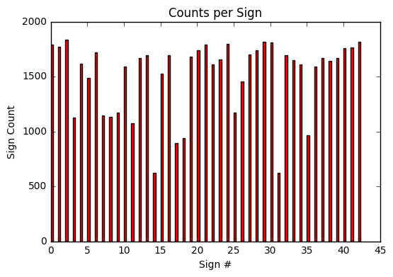

```python
showHistogram()
```

```python
import tensorflow as tf


# Hyperparameters
EPOCHS = 60
BATCH_SIZE = 128
DROPOUT_VAL = 0.5
rate = 0.001
mu = 0
sigma = 0.1

#model parameters
filter_width = 3
filter_height = 3
colors = 3
conv1_filters = 16  #128
conv2_filters = 128 #256
fc0_shape = 8*8*conv2_filters   #SAME, for Valid, it is 5*5*conv2_filters
fc1_shape = 1000
fc2_shape = 400 #1000
# n_classes
```

```python
from tensorflow.contrib.layers import flatten

def TSCNet(x, dropout):

    # SOLUTION: Layer 1: Convolutional. Input = 32x32x3. Output = 28x28xconv1_filters.
    conv1_W = tf.get_variable("conv1w",shape=[filter_width, filter_height, colors, conv1_filters], initializer=tf.contrib.layers.xavier_initializer())
    conv1_b = tf.get_variable("conv1b",shape=[conv1_filters],initializer=tf.contrib.layers.xavier_initializer())
    conv1   = tf.nn.conv2d(x, conv1_W, strides=[1, 1, 1, 1], padding='SAME') + conv1_b

    # SOLUTION: Activation.
    conv1 = tf.nn.relu(conv1)

    # SOLUTION: Pooling. Input = 28x28xconv1_filters. Output = 14x14xconv1_filters.
    conv1 = tf.nn.max_pool(conv1, ksize=[1, 2, 2, 1], strides=[1, 2, 2, 1], padding='SAME')

    # SOLUTION: Layer 2: Convolutional. Output = 10x10xconv2_filters.
    conv2_W = tf.get_variable("conv2w",shape=[filter_width, filter_height, conv1_filters, conv2_filters],initializer=tf.contrib.layers.xavier_initializer())
    conv2_b = tf.get_variable("conv2b",shape=[conv2_filters],initializer=tf.contrib.layers.xavier_initializer())
    conv2   = tf.nn.conv2d(conv1, conv2_W, strides=[1, 1, 1, 1], padding='SAME') + conv2_b

    # SOLUTION: Activation.
    conv2 = tf.nn.relu(conv2)

    # SOLUTION: Pooling. Input = 10x10xconv2_filters. Output = 5x5xconv2_filters.
    conv2 = tf.nn.max_pool(conv2, ksize=[1, 2, 2, 1], strides=[1, 2, 2, 1], padding='SAME')

    # SOLUTION: Flatten. Input = 5x5xconv2_filters. Output = fc0_shape.
    fc0   = flatten(conv2)

    # SOLUTION: Layer 3: Fully Connected. Input = fc0_shape. Output = fc1_shape.
    fc1_W = tf.get_variable("fc1w",shape=[fc0_shape, fc1_shape], initializer=tf.contrib.layers.xavier_initializer())
    fc1_b = tf.get_variable("fc1b",shape=[fc1_shape],initializer=tf.contrib.layers.xavier_initializer())
    fc1   = tf.matmul(fc0, fc1_W) + fc1_b

    # SOLUTION: Activation.
    fc1    = tf.nn.relu(fc1)
    fc1    = tf.nn.dropout(fc1,dropout)

    # SOLUTION: Layer 4: Fully Connected. Input = fc1_shape. Output = fc2_shape.
    fc2_W  = tf.get_variable("fc2w",shape=[fc1_shape, fc2_shape], initializer=tf.contrib.layers.xavier_initializer())
    fc2_b  = tf.get_variable("fc2b",shape=[fc2_shape],initializer=tf.contrib.layers.xavier_initializer())
    fc2    = tf.matmul(fc1, fc2_W) + fc2_b

    # SOLUTION: Activation.
    fc2    = tf.nn.relu(fc2)
    fc2    = tf.nn.dropout(fc2,dropout)

    # SOLUTION: Layer 5: Fully Connected. Input = fc2_shape. Output = n_classses.
    fc3_W  = tf.get_variable("fc3w",shape=[fc2_shape, n_classes], initializer=tf.contrib.layers.xavier_initializer())
    fc3_b  = tf.get_variable("fc3b",shape=[n_classes],initializer=tf.contrib.layers.xavier_initializer())
    logits = tf.matmul(fc2, fc3_W) + fc3_b

    return logits
```

```python
#input variables
x = tf.placeholder(tf.float32, (None, 32, 32, 3))
y = tf.placeholder(tf.int32, (None))
one_hot_y = tf.one_hot(y, n_classes)
keep_prob = tf.placeholder(tf.float32)
```

```python
#training pipeline
logits = TSCNet(x, keep_prob)
cross_entropy = tf.nn.softmax_cross_entropy_with_logits(logits, one_hot_y)
loss_operation = tf.reduce_mean(cross_entropy)
optimizer = tf.train.AdamOptimizer(learning_rate = rate)
training_operation = optimizer.minimize(loss_operation)
```

```python
#model evaluation
just_predictions = tf.argmax(logits, 1)
correct_prediction = tf.equal(tf.argmax(logits, 1), tf.argmax(one_hot_y, 1))
accuracy_operation = tf.reduce_mean(tf.cast(correct_prediction, tf.float32))
softmax = tf.nn.softmax(logits)


def evaluate(X_data, y_data, normalizeData=True):
    num_examples = len(X_data)
    total_accuracy = 0
    sess = tf.get_default_session()
    for offset in range(0, num_examples, BATCH_SIZE):
        batch_x, batch_y = X_data[offset:offset+BATCH_SIZE], y_data[offset:offset+BATCH_SIZE]
        if normalizeData is True:
            batch_x = batch_x - centerBy;
            batch_x = batch_x/255. * 0.8 + 0.1
        accuracy = sess.run(accuracy_operation, feed_dict={x: batch_x, y: batch_y, keep_prob: 1.0})
        total_accuracy += (accuracy * len(batch_x))
    return total_accuracy / num_examples
```

```python
#accuracygraph parameters
logBatchFrequency = 100
totalSamples = 0
samples = []
sampleTrainingAccuracy = []
sampleValidationAccuracy = []
sampleLossValue = []
```

```python
#train the model
import time
start_time = time.time()

with tf.Session() as sess:
    sess.run(tf.global_variables_initializer())
    num_examples = len(X_train)

    print("Training...")
    print()
    print("EPOCH    Validation Accuracy")
    for i in range(EPOCHS):
        X_train, y_train = shuffle(X_train, y_train)
#        batches_pbar = tqdm(range(int(num_examples/BATCH_SIZE)), desc='Epoch {:>2}/{}'.format(i + 1, EPOCHS), unit='batches')
        batches_pbar = int(num_examples/BATCH_SIZE)
        for batch_i in range(batches_pbar):
            offset = batch_i * BATCH_SIZE
            end = offset + BATCH_SIZE
            batch_x, batch_y = X_train[offset:end], y_train[offset:end]
            _, loss = sess.run([training_operation, loss_operation], feed_dict={x: batch_x, y: batch_y, keep_prob: DROPOUT_VAL})

            #take sample for graphing purpose
            if (batch_i % logBatchFrequency) is 0:
                training_accuracy = evaluate(batch_x, batch_y, normalizeData=False)
                idx = np.random.randint(len(X_valid), size=int(BATCH_SIZE * .2))
                validation_accuracy = evaluate(X_valid[idx,:], y_valid[idx], normalizeData=True)
                totalSamples += logBatchFrequency
                samples.append(totalSamples)
                sampleLossValue.append(loss)
                sampleTrainingAccuracy.append(training_accuracy)
                sampleValidationAccuracy.append(validation_accuracy)


        validation_accuracy = evaluate(X_valid, y_valid,normalizeData=True)
        print("{:<4}        {:<5.3f}".format(i+1,validation_accuracy))

    try:
        saver
    except NameError:
        saver = tf.train.Saver()
    saver.save(sess, 'tscnet')
    print("Model saved")

print()
elapsed_time = np.round((time.time() - start_time)/60.0)
print("Total Training Time ~ {} Minutes".format(elapsed_time))
```

```
Training...

EPOCH    Validation Accuracy
1           0.745
2           0.934
3           0.970
4           0.973
5           0.980
6           0.985
7           0.987
8           0.988
9           0.991
10          0.988
11          0.990
12          0.990
```

[output cut: 51 more lines]

```python
def plotAccuracyGraph():
    loss_plot = plt.subplot(211)
    loss_plot.set_title('Loss')
    loss_plot.plot(samples, sampleLossValue, 'g')
    #loss_plot.set_xlim([batches[0], batches[-1]])
    acc_plot = plt.subplot(212)
    acc_plot.set_title('Accuracy')
    acc_plot.plot(samples, sampleTrainingAccuracy, 'r', label='Training Accuracy')
    acc_plot.plot(samples, sampleValidationAccuracy, 'b', label='Validation Accuracy')
    acc_plot.set_ylim([0, 1.0])
    #acc_plot.set_xlim([batches[0], batches[-1]])
    acc_plot.legend(loc=4)
    plt.tight_layout()
    plt.show()
```

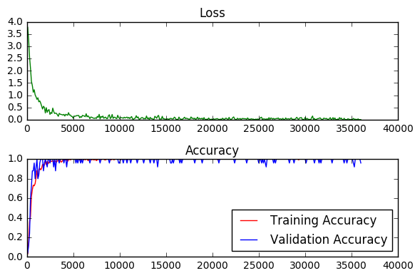

```python
plotAccuracyGraph()
```

```python
#evaluate model with test data
with tf.Session() as sess:
    loader = tf.train.import_meta_graph('tscnet.meta')
    loader.restore(sess, tf.train.latest_checkpoint('./'))

    test_accuracy = evaluate(X_test, y_test,normalizeData=True)
    print("Test Accuracy = {:.3f}".format(test_accuracy))
```

```
Test Accuracy = 0.906
```

### Question 1

*Describe how you preprocessed the data. Why did you choose that technique?*

**Answer:**

### Question 2

*Describe how you set up the training, validation and testing data for your model. **Optional**: If you generated additional data, how did you generate the data? Why did you generate the data? What are the differences in the new dataset (with generated data) from the original dataset?*

**Answer:**

20% of training data was split and used as validation data. Testing data was not used at all during training time.

After generating histogram of various classes, it was observed that some of the classes were much under-represented. We added more data for such classes by using rotations (upto 20 degrees) and affine/shear transformations. Such data augmentation technique can be used for all images, instead of only for under-represented classes, but that experiment did not yield significantly different results.

### Question 3

*What does your final architecture look like? (Type of model, layers, sizes, connectivity, etc.) For reference on how to build a deep neural network using TensorFlow, see Deep Neural Network in TensorFlow from the classroom.*

**Answer:**

I started from LeNet architecture, but changed the filter sizes to accomodate the higher number of classes in our experiement.

The final architecture was as follows First layer is a CNN with filter size of 3*3, stride of 1*1, SAME padding, depth of 16, followed by a RELU activation layer, and followed by a MAX POOLING layer of filter size 2*2, and stride 2*2 Second layer is a CNN with filter size of 3*3, stride of 1*1, SAME padding, depth of 128, followed by a RELU activation layer, and followed by a MAX POOLING layer of filter size 2*2, and stride 2*2 three Fully connected layers are followed thereafter, with depth of 1000, 400, and finally the last fully connected layer of size equal to the number of labels/classes(=43)

Dropout of 0.5 was used for the 1st and 2nd fully connected layers. This reduced overfitting and improved our test accuracy.

### Question 4

*How did you train your model? (Type of optimizer, batch size, epochs, hyperparameters, etc.)*

**Answer:**

Adam optimizer with a learning rate of 0.001 was used I ran upto 60 eopchs, after which the validation accuracy did not seem to change much.

batch_size was 128, and since I was working on AWS-GPU instance, I checked "nvidia-smi" tool to ensure that memory utilization was not exceeding.

mu of 0 and sigma of 0.1, were the other hyperparameters which were not experimented with.

### Question 5

*What approach did you take in coming up with a solution to this problem? It may have been a process of trial and error, in which case, outline the steps you took to get to the final solution and why you chose those steps. Perhaps your solution involved an already well known implementation or architecture. In this case, discuss why you think this is suitable for the current problem.*

**Answer:**

LeNet was an architecture that was useful on image classification, so that seemed a good starting point. Increasing in the number of filters, both in the convolutional layers as well as fully connected layers to compensate for the variety in the image features. Number of epochs was kept to 60 as the validation accuracy did not seem to improve.

Plotting of loss and training and validation accuracy, against the batch/epochs helped understand the nature of learning, learning rate, as well as possibly overfitting times. Dropout also helped reduce the overfitting.

Overall, it was a case of manual/semi-structured search over the hyperparameters and model parameters. More insight needs to be developed in this area.

## Step 3: Test a Model on New Images

Take several pictures of traffic signs that you find on the web or around you (at least five), and run them through your classifier on your computer to produce example results. The classifier might not recognize some local signs but it could prove interesting nonetheless.

You may find `signnames.csv` useful as it contains mappings from the class id (integer) to the actual sign name.

### Implementation

Use the code cell (or multiple code cells, if necessary) to implement the first step of your project. Once you have completed your implementation and are satisfied with the results, be sure to thoroughly answer the questions that follow.

```python
def convert_image_files_in_dir(dir):
    """
    Use the Pillow Image object to read and resize images in the
    specified directory - converting them to numpy arrays for ML
    processing.
    """
    image_list = []

    for file in os.listdir(dir):
        image = Image.open(dir + "/" + file)
        image = image.convert("RGB")
        image = image.resize((32, 32), Image.ANTIALIAS)
        image = np.array(list(image.getdata()), dtype="uint8")
        image = np.reshape(image, (32, 32, 3))
        image_list.append(image)

    return np.array(image_list)
```

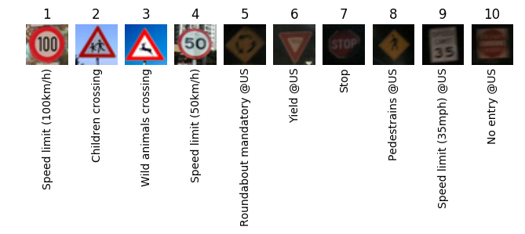

```python
#batch_x = convert_image_files_in_dir("images")
batch_x = convert_image_files_in_dir("new-images")

new_image_labels = ['Speed limit (100km/h)',
                    'Children crossing',
                    'Wild animals crossing',
                    'Speed limit (50km/h)',
                    'Roundabout mandatory @US',
                    'Yield @US',
                    'Stop',
                    'Pedestrains @US',
                    'Speed limit (35mph) @US',
                    'No entry @US',
                   ]
new_image_num = len(new_image_labels)
plt.figure(figsize=(8,1))
plt.axis("off")  # clear x- and y-axes

for i, image in enumerate(batch_x):
    plt.subplot(1,new_image_num,i+1)
    plt.axis("off")  # clear x- and y-axes
    plt.imshow(image)
    plt.text(12, 40, new_image_labels[i], rotation=90)
    plt.title(i+1)

plt.show()
```

### Question 6

*Choose five candidate images of traffic signs and provide them in the report. Are there any particular qualities of the image(s) that might make classification difficult? It could be helpful to plot the images in the notebook.*

**Answer:**

Above 10 images were chosen for new image prediction. 4 of these images were common to the ones seen in our learning dataset, whereas rest 6 images were not previously seen. Out of these remaining 6, some of the characteristics, such as Pedestrian, and Roundabout had characteristics which had no common elements to the training dataset. 2 of the images, speed limits of 35 and 100 had common visual patterns to the learning images

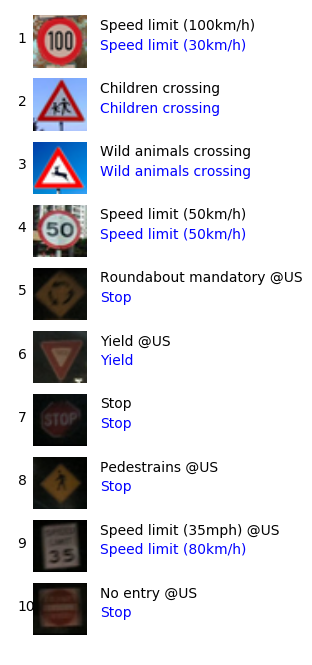

```python
### Run the predictions here.
### Feel free to use as many code cells as needed.
#evaluate model with test data

#apply normalization on new data
batch_x1 = batch_x - centerBy;
batch_x1 = batch_x1/255. * 0.8 + 0.1

with tf.Session() as sess:
    loader = tf.train.import_meta_graph('tscnet.meta')
    loader.restore(sess, tf.train.latest_checkpoint('./'))
    predictions = sess.run(just_predictions, feed_dict={x: batch_x1,keep_prob: 1.0})

plt.figure(figsize=(8,8))

for i, sign_pred in enumerate(predictions):
    plt.subplot(new_image_num,1,i+1)
    plt.imshow(batch_x[i])
    plt.text(40, 8, new_image_labels[i], rotation=0)  # Ground truth is black
    plt.text(40, 20, signnames.SignName[sign_pred], rotation=0, color='b')  # Prediction is blue
    plt.text(-10, 16, i+1);
    plt.axis('off');

plt.show()
```

### Question 7

*Is your model able to perform equally well on captured pictures when compared to testing on the dataset? The simplest way to do this check the accuracy of the predictions. For example, if the model predicted 1 out of 5 signs correctly, it's 20% accurate.*

**NOTE:** You could check the accuracy manually by using `signnames.csv` (same directory). This file has a mapping from the class id (0-42) to the corresponding sign name. So, you could take the class id the model outputs, lookup the name in `signnames.csv` and see if it matches the sign from the image.

**Answer:**

Sign#1, speed limit of 100, was something we had trained on, but the prediction was incorrect. This is a confusing result, and needs further study.

Also, our overall testing accuracy was 90.6%, and the overall training accuracy was 99.7%. and our overall testing/prediction accuracy for these new set of 10 images was 5/10, so 50%. So, the real world accuracy was not close because the dataset seen during training and during real world testing was completely different (at least in 4 of those images.). For the images that were similar to the training dataset, we achieved 4/5 about 80% accuracy. That one image, 100 speed limit, is confounding as to why the prediction was so off-base. Softmax probability also suggests that our model was confident in the wrong option, so this is certainly needs to be re-visited.

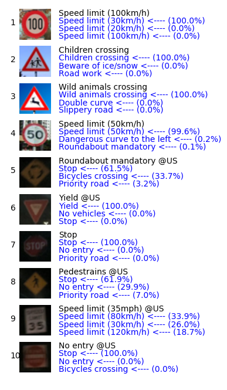

```python
### Visualize the softmax probabilities here.

with tf.Session() as sess:
    loader = tf.train.import_meta_graph('tscnet.meta')
    loader.restore(sess, tf.train.latest_checkpoint('./'))
    topk = sess.run(tf.nn.top_k(tf.nn.softmax(logits), k=3), feed_dict={x: batch_x1, keep_prob: 1.0})

plt.figure(figsize=(8,8))

for i in range(new_image_num):

    plt.subplot(new_image_num,1,i+1)
    plt.imshow(batch_x[i])
    plt.text(40, 6, new_image_labels[i], rotation=0)  # Ground truth is black

    y_position = 14
    for prob, idx in zip(topk.values[i], topk.indices[i]):
        pred_info = signnames.SignName[idx] + ' <---- (' + str(np.round(prob*100, 1)) + '%)'
        plt.text(40, y_position, pred_info, rotation=0, color='b')  # Prediction is blue
        y_position += 8

    plt.text(-10, 16, i+1);

    plt.axis('off');

plt.show()
```

### Question 8

*Use the model's softmax probabilities to visualize the **certainty** of its predictions, [`tf.nn.top_k`](https://www.tensorflow.org/versions/r0.12/api_docs/python/nn.html#top_k) could prove helpful here. Which predictions is the model certain of? Uncertain? If the model was incorrect in its initial prediction, does the correct prediction appear in the top k? (k should be 5 at most)*

**Answer:**

Sign#1 is confusing in the sense that the prediction is wrong, and the certainty of that prediction is also very high..